| 주차 | 일정 | 페이지 |
| --- | --- | --- |
| 1 | 1장-헬로 파이썬 | 0p ~ 45p |
| 2 | 2장-퍼셉트론 | 46p ~ 62p |
| 3 | 3장-신경망 | 63p ~ 105p |
| 4 | 4장-신경망 학습 | 106p ~ 146p |
| 5 | 5장-오차역전파법 | 147p ~ 187p (+ Appendix A, 292p ~ 299p) |
| 6 | 중간고사(전) |  |
| 7 | 중간고사 |  |
| 8 | 6장-학습 관련 기술들 | 188p ~ 226p |
| 9 | 7장-합성곱 신경망(CNN) | 227p ~ 259p |
| 10 | 딥러닝 | 261p ~ 308p |
| 11 | 1장-신경망 복습 | 0p ~ 74p (+ Appendix A, 389p ~ 394p) |
| 12 | 2장-자연어와 단어의 분산 표현 | 78p ~ 113p (+ Appendix B, 395p ~ 399p) |
| 13 | 기말고사(전) |  |
| 14 | 기말고사 |  |
| 15 | 3장-word2vec | 114p ~ 147p |
| 16 | 4장-word2vec 속도 개선 | 148p ~ 189p |
| 17 | 5장-순환신경망(RNN) | 190p ~ 235p |
| 18 | 6장-게이트가 추가된 RNN | 263p ~ 286p (+ Appendix C, 401p ~ 402p) |
| 19 | 7장-RNN을 사용한 문장 생성 | 287p ~ 333p |
| 20 | 8장-어텐션 | 334p ~ 387p |

# 17주차

순환신경망(RNN)

*190p ~ 235p*

지금까지 다룬 NN들은 신경망에서 정보의 흐름이 단방향인 형태이다. 구성이 간단해서 보기 쉽고 구현하기도 쉽지만 시계열 데이터 예측에서는 약하다는 단점이 있다. 이래서 순환신경망인 RNN이 등장하게 된 배경이 되었다.

### 5-1

**Word2Vec의 관점으로 보았을떄....**

1. CBOW 모델의 확률화
   - 문장 내 단어들을 $w_1, w_2, \dots, w_T$라 할 때, 임의의 위치 $t$의 단어 $w_t$를 ‘타깃’으로, 그 앞뒤 단어 $w_{t-1}, w_{t+1}$를 ‘문맥’으로 간주한다.
   - 이때 타깃 단어가 주어진 문맥으로부터 나올 확률을

     $$ P(w_t \mid w_{t-1}, w_{t+1}) $$

     와 같이 모델링한다.
2. 문맥 범위 제한
   - 예시로 왼쪽 두 단어 $w_{t-2}, w_{t-1}$만 문맥으로 고려할 경우

     $$ P(w_t \mid w_{t-2}, w_{t-1}) $$

     와 같이 식이 바뀐다.
3. 손실 함수와 학습 목표
   - 손실 함수는 타깃 단어 확률의 로그를 취한 음수, 즉

     $$ L = -\log P(w_t \mid \text{문맥}) $$

     로 정의된다. 이는 교차 엔트로피 오차와 같다.
   - 학습 과정은 이 손실 함수를 최소화하도록 매개변수를 조정하는 것이다.
4. 결과와 활용
   - 학습을 통해 얻은 단어 분산 표현(임베딩)은 문맥 정보를 잘 반영한다.
   - 이렇게 학습된 CBOW 모델은 ‘문맥으로부터 단어를 예측하는’ 언어 모델로 활용할 수 있다.

**TL;DR**

- CBOW는 주변 단어로 타깃 단어의 확률을 모델링한다.
- 손실은 $-\log$ 확률이며, 이를 최소화해 단어 임베딩을 학습한다.

대신 곱셈 정리(체인룰)를 이용해 전체 확률을 앞선 단어들이 조건이 된 사후 확률들의 곱으로 분해하는 방식이다. 다시 말해 첫 번째 단어의 확률에 이어 두 번째 단어가 첫 번째 단어 뒤에 올 확률, 세 번째 단어가 앞의 두 단어 뒤에 올 확률을 차례로 곱해 나가는 방식이다.

이렇게 분해된 조건부 확률을 학습한 결과 언어 모델은 다음 단어 예측, 문장 생성, 기계 번역 등 다양한 응용에 활용되는 것이다.

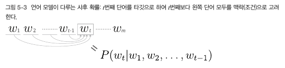

#### CBOW를 word2vec에 우겨넣기

CBOW 모델을 언어 모델로 적용하려면 전체 단어 시퀀스의 동시 확률을 고정된 크기의 문맥만을 조건으로 한 사후 확률들의 곱으로 근사하면 된다.

이때 왼쪽 k개의 단어만 맥락으로 고려하여 $P(w_t \mid w_{t-k}, \dots, w_{t-1})$의 곱으로 전체 확률 $P(w_1,\dots,w_m)$을 근사하는 방식이다. 이러한 근사는 Markov 가정에 기반한 n-gram 모델과 동일한 개념이다.

CBOW는 맥락 단어 벡터를 은닉층에서 합산하여 은닉 표현을 만든 뒤 출력층에서 타깃 단어 확률을 계산한다. 이 과정에서 단어 순서는 무시되어 bag-of-words 특성을 띤다.

순서를 반영하려면 벡터를 연결(concatenate)하는 방법을 사용할 수 있으나 매개변수 수가 크게 증가한다. RNN은 순차적 기억 메커니즘을 지녀 무한 길이의 문맥 정보도 처리할 수 있어 이러한 한계를 극복할 수 있다.

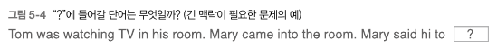

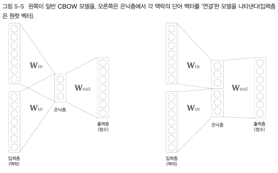

### 5-2

RNN이란 Recurrent Neural Network의 약자이다.

RNN은 순환 경로를 포함한 구조로 이전 시점의 은닉 상태를 다음 시점의 처리에 조건으로 제공하는 방식이다. 이 순환 경로는 데이터를 끊임없이 순환시키며 과거 정보를 반복적으로 기억하고 새로운 입력을 최신 상태로 갱신하는 메커니즘이다.

RNN 계층은 각 시점의 입력 벡터 $x_t$를 받아 내부 셀을 통해 은닉 상태 $h_t$를 생성하는 구조이다. 은닉 상태는 다음 시점의 입력과 결합되어 다시 RNN 셀로 전달되며 이 과정을 통해 시계열 데이터의 장기 의존성을 처리할 수 있다.

> TL;DR: RNN은 순환 경로를 통해 시퀀스 데이터를 처리하며 과거 정보를 은닉 상태로 기억해 장기 의존성을 학습하는 신경망이다.

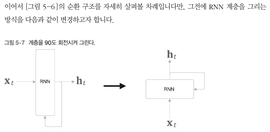

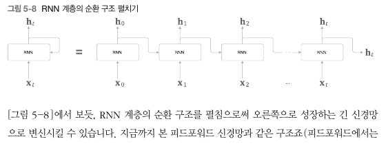

RNN 계층은 실제로 하나의 셀을 시간 축만큼 복제해 펼쳐 놓은 형태로 볼 수 있으나, 모든 복제본은 동일한 가중치를 사용하는 ‘같은 계층’이다. 펼쳐진 구조를 그리는 방식은 일반적인 오른쪽 방향 전개와 함께 이 책에서 제시하는 수직 방향 전개 두 가지가 있으며, 후자는 출력과 다음 시점 은닉 상태 전달을 명확히 구분해 보여 준다.

결과적으로 RNN은 순환 경로를 통해 과거 정보를 계속 순환시키며, 그 상태 벡터를 다음 입력 처리에 활용하는 메모리(기억력)를 지닌 신경망이다.

BPTT(Back Propagation Through Time)는 RNN을 시간 축을 따라 가로로 펼친 뒤 일반적인 피드포워드 신경망처럼 순전파와 역전파를 순차적으로 적용해 기울기를 계산하는 알고리즘이다.

펼쳐진 RNN 계층은 매 시점의 입력과 은닉 상태를 모두 메모리에 유지해야 하므로, 역전파를 위해 전체 순환 구조가 한꺼번에 저장되어야 한다는 특징이 있다. 이로 인해 시퀀스 길이가 늘어날수록 순전파, 역전파에 필요한 계산량과 메모리 사용량이 기하급수적으로 증가한다.

또한 긴 시계열에서는 역전파 시 기울기 소실(vanishing) 또는 폭주(exploding) 현상이 발생해 학습이 불안정해진다는 한계가 있다.

이 문제를 완화하고자 Truncated BPTT가 등장했다. 말 그대로 시계열 상에서 context 블록으로 쪼개서 학습을 진행하는 것이다. 이렇게 하면 메모리 과부화 문제를 완화해주고 또 병렬처리도 가능해진다. 다음과 같이 쪼갬:

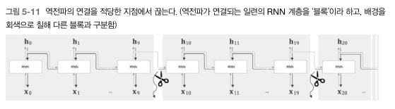

note: 역전파(훈련)시에만 연결을 끊고 순전파/inference시에는 유지함.

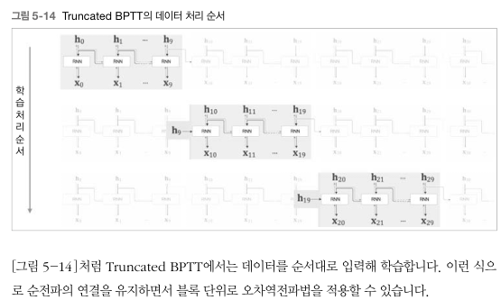

**T-BPTT의 배치학습**

각 미니배치에 대해 RNN 순전파와 역전파를 수행하며, 다음 미니배치 학습을 위해 이전 미니배치의 마지막 은닉 상태를 초기 은닉 상태로 유지한 채 이어서 처리하는 방식이다. 이 과정에서 미니배치마다 시작 위치를 오프셋만큼 이동시키며 데이터를 순서대로 공급함으로써 연속된 시퀀스 정보를 유지하면서도 메모리 사용량과 계산 비용을 절감할 수 있는 것이다.

실제 구현에서는 소스 코드에서 각 미니배치의 입력 구간과 은닉 상태 전달을 명시적으로 관리하는 방식이다.

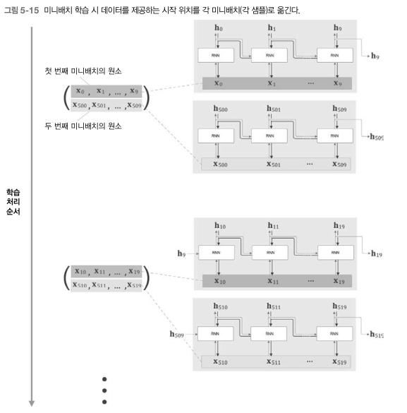

### 5-3

#### RNN 구현

RNN에서 쓰이는 한 노드의 계산 그래프를 보면 다음과 같다.

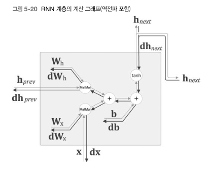

(역전파 + 순전파)

```python
import sys
sys.path.append('..')
from common.np import *
from common.layers import *
from common.functions import sigmoid


class RNN:
    def __init__(self, Wx, Wh, b):
        self.params = [Wx, Wh, b]
        self.grads = [np.zeros_like(Wx), np.zeros_like(Wh), np.zeros_like(b)]
        self.cache = None  # 역전파에 사용할 중간 데이터

    def forward(self, x, h_prev):
        Wx, Wh, b = self.params
        t = np.matmul(h_prev, Wh) + np.matmul(x, Wx) + b
        h_next = np.tanh(t)

        self.cache = (x, h_prev, h_next)
        return h_next

    def backward(self, dh_next):
        Wx, Wh, b = self.params
        x, h_prev, h_next = self.cache

        dt = dh_next * (1 - h_next ** 2)  # tanh 미분
        db = np.sum(dt, axis=0)
        dWh = np.dot(h_prev.T, dt)  # shape: (H, N) x (N, H) = (H, H)
        dh_prev = np.dot(dt, Wh.T)  # shape: (N, H) x (H, H) = (N, H)
        dWx = np.dot(x.T, dt)  # shape: (D, N) x (N, H) = (D, H)
        dx = np.dot(dt, Wx.T)  # shape: (N, H) x (H, D) = (N, D)

        self.grads[0][...] = dWx
        self.grads[1][...] = dWh
        self.grads[2][...] = db

        return dx, dh_prev
```

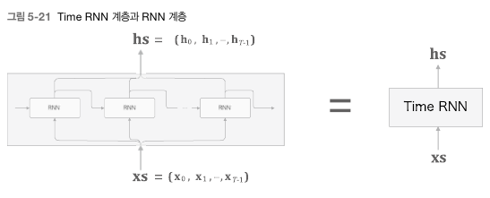

`TimeRNN`은 RNN의 은닉층에 있는 time sequence로 표현된 노드를 상징함.

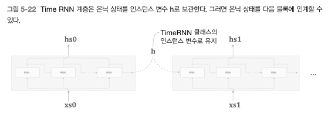

truncated된 부분 또한 위의 인스턴스 변수로 표현을 한다.

```python
class TimeRNN:
    def __init__(self, Wx, Wh, b, stateful=False):
        self.params = [Wx, Wh, b]
        self.grads = [np.zeros_like(Wx), np.zeros_like(Wh), np.zeros_like(b)]
        self.layers = None  # RNN 계층을 리스트로 저장

        self.h, self.dh = None, None
        self.stateful = stateful

    def set_state(self, h):
        '''hidden state(h)를 설정하는 메서드'''
        self.h = h

    def reset_state(self):
        '''hidden state(h)를 초기화하는 메서드'''
        self.h = None

    def forward(self, xs):
        Wx, Wh, b = self.params
        N, T, D = xs.shape  # N(batch), T(time steps), D(input size)
        D, H = Wx.shape

        self.layers = []
        hs = np.empty((N, T, H), dtype='f')

        if not self.stateful or self.h is None:
            self.h = np.zeros((N, H), dtype='f')

        for t in range(T):
            layer = RNN(*self.params)
            self.h = layer.forward(xs[:, t, :], self.h)
            hs[:, t, :] = self.h
            self.layers.append(layer)

        return hs

    def backward(self, dhs):
        Wx, Wh, b = self.params
        N, T, H = dhs.shape
        D, H = Wx.shape

        dxs = np.empty((N, T, D), dtype='f')
        dh = 0
        grads = [0, 0, 0]
        for t in reversed(range(T)):
            layer = self.layers[t]
            dx, dh = layer.backward(dhs[:, t, :] + dh)  # 합산된 기울기
            dxs[:, t, :] = dx

            for i, grad in enumerate(layer.grads):
                grads[i] += grad

        for i, grad in enumerate(grads):
            self.grads[i][...] = grad
        self.dh = dh

        return dxs
```

note: 되먹임 진행되는 파트에서는 역전파시, 기울기가 합산이 되어 전달이 된다.

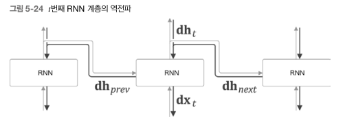

### 5-4

앞서 배운 Language Model과 이제 RNN을 합해서 RNN을 쓰는 LM인 RNNLM을 구성해보겠다.

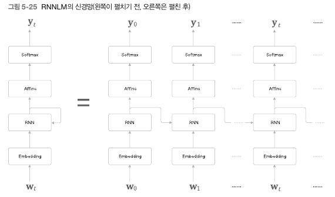

구성을 해서 문장을 feed한 다음 나온 결과를 시각화해보면 다음과 같은 결과가 나온다.

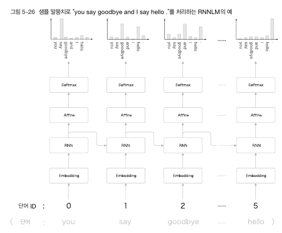

각 token(단어)마다 다음에 올 단어들의 확률로 출력값이 나온다.

you 다음에는 say가 가장 나오기 그럴듯 하게 훈련이 되어 you에 대한 답으로 say가 가장 높은 확률로 (당연히) 나옴을 확인할 수 있다.

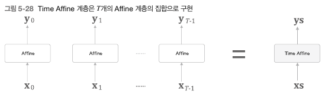

> Time 계층은 시계열 데이터를 한 번에 처리하기 위해 Embedding, RNN, Affine, Softmax with Loss 계층을 시퀀스 축에 맞춰 블록처럼 묶은 구조이다. Time Embedding 계층은 각 시점 입력을 처리하는 Embedding 레이어를 T개 준비하거나 배치 차원으로 확장해 한 번에 처리하도록 구현된다.

```python
from common.time_layers import *

class SimpleRnnlm:
    def __init__(self, vocab_size, wordvec_size, hidden_size):
        V, D, H = vocab_size, wordvec_size, hidden_size
        rn = np.random.randn

        # 가중치 초기화 (Xavier initialization)
        embed_W = (rn(V, D) / 100).astype('f')
        rnn_Wx = (rn(D, H) / np.sqrt(D)).astype('f')
        rnn_Wh = (rn(H, H) / np.sqrt(H)).astype('f')
        rnn_b = np.zeros(H).astype('f')
        affine_W = (rn(H, V) / np.sqrt(H)).astype('f')
        affine_b = np.zeros(V).astype('f')

        # 계층 생성
        self.layers = [
            TimeEmbedding(embed_W),
            TimeRNN(rnn_Wx, rnn_Wh, rnn_b, stateful=True),
            TimeAffine(affine_W, affine_b),
        ]
        self.loss_layer = TimeSoftmaxWithLoss()
        self.rnn_layer = self.layers[1]

        # 모든 가중치와 기울기를 리스트에 모은다.
        self.params, self.grads = [], []
        for layer in self.layers:
            self.params += layer.params
            self.grads += layer.grads

    def forward(self, xs, ts):
        for layer in self.layers:
            xs = layer.forward(xs)
        loss = self.loss_layer.forward(xs, ts)
        return loss

    def backward(self, dout=1):
        dout = self.loss_layer.backward(dout)
        for layer in reversed(self.layers):
            dout = layer.backward(dout)
        return dout

    def reset_state(self):
        self.rnn_layer.reset_state()
```

```
말뭉치 크기: 1000, 어휘 수: 418
| 에폭 1 | 퍼플렉서티 395.00
| 에폭 2 | 퍼플렉서티 270.92
| 에폭 3 | 퍼플렉서티 226.47
| 에폭 4 | 퍼플렉서티 215.94
| 에폭 5 | 퍼플렉서티 206.57
| 에폭 6 | 퍼플렉서티 202.00
| 에폭 7 | 퍼플렉서티 198.66
| 에폭 8 | 퍼플렉서티 196.76
| 에폭 9 | 퍼플렉서티 192.31
| 에폭 10 | 퍼플렉서티 193.50
| 에폭 11 | 퍼플렉서티 189.15
| 에폭 12 | 퍼플렉서티 193.73
| 에폭 13 | 퍼플렉서티 191.41
| 에폭 14 | 퍼플렉서티 191.57
| 에폭 15 | 퍼플렉서티 191.69
| 에폭 16 | 퍼플렉서티 188.08
| 에폭 17 | 퍼플렉서티 186.02
| 에폭 18 | 퍼플렉서티 182.35
| 에폭 19 | 퍼플렉서티 183.99
| 에폭 20 | 퍼플렉서티 185.14
| 에폭 21 | 퍼플렉서티 183.82
| 에폭 22 | 퍼플렉서티 180.05
| 에폭 23 | 퍼플렉서티 177.18
| 에폭 24 | 퍼플렉서티 178.66
| 에폭 25 | 퍼플렉서티 176.33
| 에폭 26 | 퍼플렉서티 176.78
| 에폭 27 | 퍼플렉서티 172.03
| 에폭 28 | 퍼플렉서티 171.23
| 에폭 29 | 퍼플렉서티 169.04
| 에폭 30 | 퍼플렉서티 163.44
| 에폭 31 | 퍼플렉서티 165.21
| 에폭 32 | 퍼플렉서티 159.92
| 에폭 33 | 퍼플렉서티 160.68
| 에폭 34 | 퍼플렉서티 155.36
| 에폭 35 | 퍼플렉서티 154.41
| 에폭 36 | 퍼플렉서티 148.57
| 에폭 37 | 퍼플렉서티 142.17
| 에폭 38 | 퍼플렉서티 140.36
| 에폭 39 | 퍼플렉서티 134.70
```

[output cut: 46 more lines]

```
| 에폭 86 | 퍼플렉서티 12.63
| 에폭 87 | 퍼플렉서티 12.29
| 에폭 88 | 퍼플렉서티 10.82
| 에폭 89 | 퍼플렉서티 10.63
| 에폭 90 | 퍼플렉서티 10.33
| 에폭 91 | 퍼플렉서티 9.47
| 에폭 92 | 퍼플렉서티 9.17
| 에폭 93 | 퍼플렉서티 8.56
| 에폭 94 | 퍼플렉서티 8.38
| 에폭 95 | 퍼플렉서티 7.82
| 에폭 96 | 퍼플렉서티 7.67
| 에폭 97 | 퍼플렉서티 7.34
| 에폭 98 | 퍼플렉서티 6.54
| 에폭 99 | 퍼플렉서티 6.60
| 에폭 100 | 퍼플렉서티 6.08
```

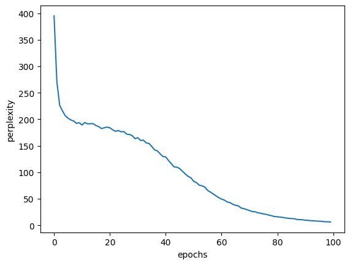

```python
import matplotlib.pyplot as plt
import numpy as np
from common.optimizer import SGD
from dataset import ptb


# 하이퍼파라미터 설정
batch_size = 10
wordvec_size = 100
hidden_size = 100 # RNN의 은닉 상태 벡터의 원소 수
time_size = 5     # Truncated BPTT가 한 번에 펼치는 시간 크기
lr = 0.1
max_epoch = 100

# 학습 데이터 읽기(전체 중 1000개만)
corpus, word_to_id, id_to_word = ptb.load_data('train')
corpus_size = 1000
corpus = corpus[:corpus_size]
vocab_size = int(max(corpus) + 1)

xs = corpus[:-1]  # 입력
ts = corpus[1:]   # 출력(정답 레이블)
data_size = len(xs)
print('말뭉치 크기: %d, 어휘 수: %d' % (corpus_size, vocab_size))

# 학습 시 사용하는 변수
max_iters = data_size // (batch_size * time_size)
time_idx = 0
total_loss = 0
loss_count = 0
ppl_list = []

# 모델 생성
model = SimpleRnnlm(vocab_size, wordvec_size, hidden_size)
optimizer = SGD(lr)

# 미니배치의 각 샘플의 읽기 시작 위치를 계산
jump = (corpus_size - 1) // batch_size
offsets = [i * jump for i in range(batch_size)]

for epoch in range(max_epoch):
    for iter in range(max_iters):
        # 미니배치 취득
        batch_x = np.empty((batch_size, time_size), dtype='i')
        batch_t = np.empty((batch_size, time_size), dtype='i')
        for t in range(time_size):
            for i, offset in enumerate(offsets):
                batch_x[i, t] = xs[(offset + time_idx) % data_size]
                batch_t[i, t] = ts[(offset + time_idx) % data_size]
            time_idx += 1

        # 기울기를 구하여 매개변수 갱신
        loss = model.forward(batch_x, batch_t)
        model.backward()
        optimizer.update(model.params, model.grads)
        total_loss += loss
        loss_count += 1

    # 에폭마다 퍼플렉서티 평가
    ppl = np.exp(total_loss / loss_count)
    print('| 에폭 %d | 퍼플렉서티 %.2f'
          % (epoch+1, ppl))
    ppl_list.append(float(ppl))
    total_loss, loss_count = 0, 0

# 그래프 그리기
x = np.arange(len(ppl_list))
plt.plot(x, ppl_list, label='train')
plt.xlabel('epochs')
plt.ylabel('perplexity')
plt.show()
```

## concl.

RNN은 반복 구조 덕분에 이전 정보를 기억하는 신경망이다.

이 구조를 옆으로 펼치면 여러 개의 계층이 연결된 모습이 되며, BPTT라는 방법으로 학습한다. 긴 문장을 한꺼번에 처리하기 어렵기 때문에 일정 길이로 잘라서 한 조각씩 학습하는데, 이를 Truncated BPTT라고 한다.

Truncated BPTT에서는 뒤로 정보를 보내는 연결만 끊고 앞으로 정보를 받는 연결은 이어서 사용해야 한다.

언어 모델은 단어가 차례로 나올 확률을 계산하는 모델이며, RNN 기반 언어 모델은 지금까지 나온 모든 단어 정보를 내부 상태에 저장해 다음에 나올 단어를 예측할 수 있다.